# Take-Home Assessment 3

Create a new `Quarto` file and copy the following statement into your new file. Then sign your name (by typing it) to the statement. Note that, in this and all future quizzes and assignments, full credit will not be given unless the statement and signature are present.

**Statement of Integrity**: “All work presented is my own, and I have followed all rules for collaboration. If I used any AI on this assignment, I have clearly stated both (1) what my search prompt was and (2) what I used from the AI answer.””

**Collaboration Reminder**: You **may** work with other students **in the class** on the quiz, but you must list who you worked with at the top of your quiz. Write the name of any student(s) that you collaborated with in the space below this (ignore this if you did not collaborate with any students).

**Important**: Remember to change your header so that the rendered `.html` file is embed-resources.

```
---
title: "Your Title"
author: "Your Name"
format:
  html:
    embed-resources: true
---
```

Consider a data set collected on 75 lego sets, collected from https://www.openintro.org/data/index.php?data=lego_sample. We are interested in modeling the `price` (in dollars) of lego sets using the number of `pieces` (in number of pieces) the lego set has and the lego set `theme` (categorical with 3 levels: `City`, `DUPLO`, and `Friends`). `City` is the level that is the reference group in the fitted model.

Read in the data by downloading `lego_sample.csv` from Canvas and running:

```r
library(tidyverse)
lego_df <- read_csv(here::here("data/lego_sample.csv")) |>
  mutate(minifigures = if_else(is.na(minifigures),
                               true = 0,
                               false = minifigures))
```

A plot of the data is given below.

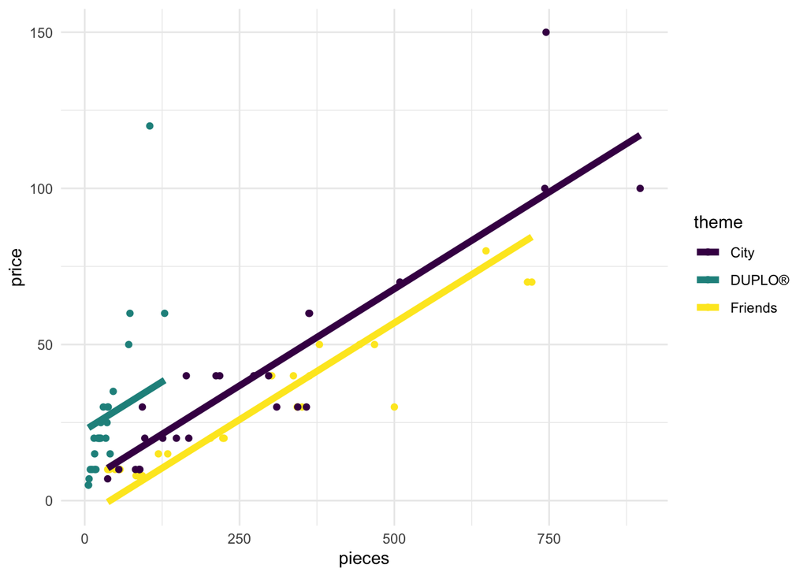

**Note**: To best prepare yourself for the handwritten quiz, it is suggested that you attempt Question 2, the interpretation from Question 4, Question 5, and Question 6 while only looking at handwritten notes.

**Question 1** (1 point). In `R`, fit the model with `pieces` and `theme` as predictors using `lm()`. Then, provide a summary tibble of output with `tidy()`.

**Question 2** (1 point). Interpret the fitted model coefficient for the `Friends` theme, $b_3$, in context of the problem.

**Question 3** (1 point). Using `augment()`, determine if there are any observations with a cook’s distance value above `0.75`, a common cut-off for determining if there are influential points.

**Question 4** (1 point). Add `minifigures`, the number of minifigures included in the set, as a predictor to the model that already has `pieces` and `theme`. Interpret the fitted model coefficient for `minifigures`, $b_4$, in context of the problem.

**Question 5** (1 point). What would an **interaction** between `theme` and `minifigures` allow for? Explain what adding an interaction between these two predictors would allow the model to do, to someone with little statistical background. (You do not need to actually add the interaction term).

**Question 6** (1 point). Suppose that you want to visualize the model with `pieces`, `theme`, and `minifigures` as predictors (with no interactions). Sketch out a visualization that incorporates all 3 predictors and the response in some way. You do not need to turn anything in for this question, but completing this may be good practice for the handwritten quiz.

**Question 7** (4 points). Construct the visualization that you sketched out in `R`.

Note that your visualization should show that an interaction term between `pieces` and `theme` would improve the model fit: the slope between `price` and `pieces` looks like it should be much steeper for the DUPLO theme than the other two themes.